# Project 6

**Zachary Jock**

**Data Oriented Computing**

**May 9, 2025**

```python
from fredapi import Fred
import pandas as pd
from sklearn.model_selection import train_test_split
from sklearn.ensemble import RandomForestClassifier
from sklearn.linear_model import LinearRegression
from sklearn.metrics import classification_report, confusion_matrix
import xgboost as xgb
import itertools
import time
import matplotlib.pyplot as plt
from tqdm import tqdm
```

```python
%pip install fredapi
%pip install xgboost
%pip install matplotlib #For some reason matplotlib wasn't installed, I put this here just in case
```

**Note:** To run XGBoost in Jupyter Notebook on MacOS you must first install the Homebrew package manager at [brew.sh](https://brew.sh/), then run `brew install libomp` and restart the Python kernel. For other platforms I have attached the official documentation [here](https://xgboost.readthedocs.io/en/stable/install.html).

# Can You Predict the Federal Reserve?

If you have an investment portfolio or trade stocks, chances are that you have some cognizance of the Federal Reserve, and you may be aware of its chairman Jerome Powell—he could either be your best friend or worst enemy depending on the day. Given that layman traders usually have less financial intuition and experience than an institutional trader, the Fed is seen as an entity that makes stocks rally or crash when Powell comes up to the podium. For an institutional trader, the monetary policy of the Fed is much easier to follow since they’ve studied the function of the Fed in school. The Federal Reserve’s primary function is to control the distribution and cost of money and credit to help promote national economic goals. (federalreserve.gov) The Fed controls the money and credit by changing the interest rate for when they lend to smaller banks. When the Fed raises interest rates, banks are deterred from borrowing and distributing money to the wider public in an effort to curtail inflation. Once the economy is under control, the Fed will cut interest rates to incentivize banks to borrow and stimulate economic growth. To determine a rate or a cut, the Fed meets 8 times a year for the Federal Open Market Committee (FOMC) where an appointed board of governors assesses the state of the economy based on statistical indicators like unemployment and Consumer Price Index (i.e. how much consumers pay for goods and services). Based on the information that the Federal Reserve provides on their policy-making process, institutional investors can study the same economic indicators as the Fed and be able to hypothesize the trajectory of the market based on what the Fed decides to do with interest rates.

For this report, we will explore an automated way of finding economic indicator charts that are the most coordinated with the monthly effective interest rate (FEDFUNDS series from FRED) and the daily effective interest rate (DFF series from FRED). To do this, we will use sklearn's implementation of the gradient boosting algorithm XGBoost to calculate which economic indicators have the most accurate score in predicting the change in FEDFUNDS and DFF. From these results, we will graph the indicators onto one chart with `matplotlib` to observe the behavior of each statistical function relative to the effective interest rate. If one is able to predict the interest rate with these economic indicators, they would have a more certain and educated outlook on how the market will react and investing/trading would be significantly less ambigious than the commonly accepted notion of "sometimes it goes up, sometimes it goes down".

## Parsing Economic Indicators

To find economic indicators from the federal reserve, we can automatically pull datasets from the Federal Reserve Economic Data website, courtesy of the St. Louis branch of the Fed using the `Fred` Python library. In order to pull these datasets, we have to establish an API key. I will put the key I used for my data in the box below but should it ever get pulled one can insert their own by making a FRED account and changing the `api_key` value. Something to keep in mind is that the terms of service prohibit the data from being used for machine learning, so by doing this we are breaking the rules--be careful not to hammer the API or mention machine learning in the API key request comment box lest you get banned from the FRED service!

```python
fred = Fred(api_key='')
```

Now that we have signed in with the API key, we can begin to search for economic indicators in the FRED database; To make this easy, we can search through the 10 most popular indicators to save on computation resources and API requests. Once we have the ID of each series we will append them to a list where we will then request the data for each series ID and create a pandas dataframe for monthly and daily series figures.

```python
daily_series = fred.search('daily').sort_values('popularity', ascending=False).head(10) #fetch most popular daily and monthly indicators from FRED
monthly_series = fred.search('monthly').sort_values('popularity', ascending=False).head(10)
daily_series_ids = daily_series['id'].tolist() #Put the most popular daily/monthly IDs into a list to be called later
monthly_series_ids = monthly_series['id'].tolist()
ds_ = {} #dictionary for daily series data
ms_ = {} #dictionary for monthly series data
date_range = pd.date_range(start='2000-01-01', end=pd.Timestamp.today(), freq='D') #define date range starting from the last 25 years
#loop through each of the IDs from our _series_ids lists and fetch FRED data, then reindex according to the date range
for d in daily_series_ids:
    series = fred.get_series(d)
    series = series.reindex(date_range).fillna(method='ffill').fillna(method='bfill')
    ds_[d] = series.diff().apply(lambda x: 2 if x > 0 else (0 if x < 0 else 1)) #derivative for the rate of change between each data point according to XGBoost spec (classes go by 0,1,2 like with standard python indexing)
    time.sleep(1) #paranoid waiting command so that I dont get my api key banned
for m in monthly_series_ids:
    series = fred.get_series(m)
    series = series.reindex(date_range).fillna(method='ffill').fillna(method='bfill')
    ms_[m] = series.diff().apply(lambda x: 2 if x > 0 else (0 if x < 0 else 1))
    time.sleep(1)
#combine into DataFrames
ds_ = pd.DataFrame(ds_).dropna()
ms_ = pd.DataFrame(ms_).dropna()
```

```python
ds_
```

|  | FEDFUNDS | RRPONTSYD | T10Y3M | DGS10 | BAMLH0A0HYM2 | DEURECD | THREEFY7 | THREEFF4 | BAMLEM4RBLLCRPIUSOAS | RIFSPPFAAD01NB |
| --- | --- | --- | --- | --- | --- | --- | --- | --- | --- | --- |
| 2000-01-01 | 1 | 1 | 1 | 1 | 1 | 1 | 1 | 1 | 1 | 1 |
| 2000-01-02 | 1 | 1 | 1 | 1 | 1 | 1 | 1 | 1 | 1 | 1 |
| 2000-01-03 | 1 | 1 | 1 | 1 | 1 | 1 | 1 | 1 | 1 | 1 |
| 2000-01-04 | 1 | 1 | 0 | 0 | 2 | 1 | 0 | 0 | 1 | 0 |
| 2000-01-05 | 1 | 1 | 2 | 2 | 0 | 1 | 2 | 2 | 1 | 2 |
| ... | ... | ... | ... | ... | ... | ... | ... | ... | ... | ... |
| 2025-05-06 | 1 | 2 | 0 | 0 | 2 | 1 | 1 | 1 | 2 | 2 |
| 2025-05-07 | 1 | 2 | 0 | 0 | 2 | 1 | 1 | 1 | 0 | 0 |
| 2025-05-08 | 1 | 0 | 2 | 2 | 0 | 1 | 1 | 1 | 0 | 2 |
| 2025-05-09 | 1 | 2 | 1 | 1 | 1 | 1 | 1 | 1 | 1 | 1 |
| 2025-05-10 | 1 | 1 | 1 | 1 | 1 | 1 | 1 | 1 | 1 | 1 |

9262 rows × 10 columns

```python
ms_
```

|  | FEDFUNDS | CPIAUCSL | UNRATE | T10Y3M | M2SL | RETAILMPCIMSA | PPIDTS | WPS5831 | TMBACBM027SBOG | AMBNS |
| --- | --- | --- | --- | --- | --- | --- | --- | --- | --- | --- |
| 2000-01-01 | 1 | 1 | 1 | 1 | 1 | 1 | 1 | 1 | 1 | 1 |
| 2000-01-02 | 1 | 1 | 1 | 1 | 1 | 1 | 1 | 1 | 1 | 1 |
| 2000-01-03 | 1 | 1 | 1 | 1 | 1 | 1 | 1 | 1 | 1 | 1 |
| 2000-01-04 | 1 | 1 | 1 | 0 | 1 | 1 | 1 | 1 | 1 | 1 |
| 2000-01-05 | 1 | 1 | 1 | 2 | 1 | 1 | 1 | 1 | 1 | 1 |
| ... | ... | ... | ... | ... | ... | ... | ... | ... | ... | ... |
| 2025-05-06 | 1 | 1 | 1 | 0 | 1 | 1 | 1 | 1 | 1 | 1 |
| 2025-05-07 | 1 | 1 | 1 | 0 | 1 | 1 | 1 | 1 | 1 | 1 |
| 2025-05-08 | 1 | 1 | 1 | 2 | 1 | 1 | 1 | 1 | 1 | 1 |
| 2025-05-09 | 1 | 1 | 1 | 1 | 1 | 1 | 1 | 1 | 1 | 1 |
| 2025-05-10 | 1 | 1 | 1 | 1 | 1 | 1 | 1 | 1 | 1 | 1 |

9262 rows × 10 columns

Before we create our machine learning function, we should first go over what XGBoost is and what it does. XGBoost, or Extreme Gradient Boosting, is a gradient-boosting machine learning algorithm that is designed to find both correlations (i.e. regression) and classification through the usage of gradient boosting, where the dataset is split into small decision trees that are too weak on their own, but the weak models are ultimately combined and optimized into a single strong model. Like other supervised machine learning algorithms, this strong decision-tree model is used to predict features or labels based on the given input data. Because of XGBoost's design being favored toward processing each decision tree in parallel, the algorithm lends itself well with scalabity and has become a favorite amongst data scientists and machine learning engineers since it can not only scale to high performance computing platforms (such as a datacenter that uses NVIDIA's CUDA platform) but can perform the same function as KNN and linear regression with state-of-the-art accuracy.

```python
def test_feature_combinations(df, feature_list, target_pred='FEDFUNDS', max_combination_size=3, top_n=10, t_size=0.2):
    date_range = pd.date_range(start='2000-01-01', end=pd.Timestamp.today(), freq='D') #date range from the last 25 years
    rate_change = fred.get_series(target_pred).reindex(date_range).fillna(method='ffill').fillna(method='bfill').diff().apply(lambda x: 2 if x > 0 else (0 if x < 0 else 1)).tolist() #add daily or monthly effective interest rates for both ds_ and ms_ respectively (the main objective!)
    results = []
    for r in tqdm(range(1, max_combination_size + 1),desc="Processing via XGBoost"): #loop through no. of all possible combinations
        for combo in itertools.combinations(feature_list, r): #loop through the combination of series IDs themselves
            X = df[list(combo)] #set particular combination for X independent variable
            y = rate_change #set the change in FEDFUNDS/DFF/etc. as Y dependent variable
            X_train, X_test, y_train, y_test = train_test_split(X, y, test_size=t_size, random_state=42) #split the data into 80% training
            model = xgb.XGBClassifier(objective='multi:softprob', num_class=3, eval_metric='mlogloss', random_state=42) #set XGBoost to find probability of X correlating with Y with the 3 outcomes: fed cut (0), fed neutral (1) and fed hike (2)
            model.fit(X_train, y_train) #apply xgb to the data!
            y_pred = model.predict(X_test) #take testing split of our X value to predict rate change based on model
            acc = classification_report(y_test, y_pred, output_dict=True,zero_division=0) #take classification report of rate change to determine accuracy amongst the three classes. zero_division is set to account for neutral (0) entries in data.
            macf1 = acc['macro avg']['f1-score'] #specifically find the average accuracy amongst all 3 classes to account for bias (we want to pick a model that can predict rare events like a cut just as well as a neutral or rate hike)
            results.append((combo, macf1)) #append combination of indicators and its associated macro average accuracy to the results list.
    results.sort(key=lambda x: x[1], reverse=True) #rank the best combinations according to top_n
    res = results[:top_n]
    results_df = pd.DataFrame(res, columns=['Economic Indicator Combination', 'Accuracy (Macro Avg.)']) #insert results into pandas dataframe
    return results_df #return results
```

## Observing XGBoost results

Prior to benchmarking each combination of indicators through XGBoost, we want to create a function that can provide the full classification report for a given list of indicators for analysis later on. Additionally, we are going to drop `FEDFUNDS` from the `monthly_series_ids` series list as well as the dataframe containing our Fed data so that we aren't comparing `FEDFUNDS` to itself.

```python
def run_xgboost_classification(df, feature_ids, target_pred):
    date_range = pd.date_range(start='2000-01-01', end=pd.Timestamp.today(), freq='D') #date range from the last 25 years
    X = df[feature_ids] #Set the series IDs in the dataframe as the independent variables
    y = fred.get_series(target_pred).reindex(date_range).fillna(method='ffill').fillna(method='bfill').diff().apply(lambda x: 2 if x > 0 else (0 if x < 0 else 1)).tolist() #set interest rates as dependent variable
    X_train, X_test, y_train, y_test = train_test_split(X, y, test_size=0.2, random_state=42) #split into 80% training data
    model = xgb.XGBClassifier(objective='multi:softprob', num_class=3, eval_metric='mlogloss', random_state=42) #set XGBoost to find probability of X correlating with Y with the 3 outcomes: fed cut (0), fed neutral (1) and fed hike (2)
    model.fit(X_train, y_train) #apply xgb to the data!
    y_pred = model.predict(X_test) #take testing split of our X value to predict rate change based on model
    print("XGBoost Classification Report:") #output full classification report
    print(classification_report(y_test, y_pred))
```

```python
ms_.drop(['FEDFUNDS'],axis=1)
monthly_series_ids.remove('FEDFUNDS')
```

In addition to running a full classification report, we should make a function that displays a given set of economic indicators to see if there is any phenomena that can be found visually that our XGBoost algorithm otherwise ignored.

```python
def fed_graph_gen(feature_ids,year):
    data = {} #store each plot in dictionary
    date_range = pd.date_range(start=f'{year}-01-01', end=pd.Timestamp.today(), freq='D') #date range from the last X years (some plots are discontinued)
    for _id in feature_ids: #loop through each series ID in list
            series = fred.get_series(_id) #pull data from FRED
            series = series.reindex(date_range).fillna(method='ffill').fillna(method='bfill') #fill any NaN values with neutral integers between data points
            data[_id] = series #assign data to each ID
    df = pd.DataFrame(data) #convert to Pandas
    df = (df - df.min()) / (df.max() - df.min()) #normalize the data from 0 to 1
    plt.figure(figsize=(12, 6)) #size of figure
    for col in df.columns:
        plt.plot(df.index, df[col], label=col) #plot each series from the given list parameter
    plt.title('FRED Series Comparison')
    plt.xlabel('Date')
    plt.ylabel('Normalized Values [0,1]')
    plt.legend()
    plt.grid(True)
    plt.tight_layout()
    plt.show()
```

With that out of the way, lets benchmark the best combination of economic indicators that will most accurately predict the effective monthly interest rate!

```python
monthly_combo = test_feature_combinations(ms_, monthly_series_ids, 'FEDFUNDS', max_combination_size=7, top_n=20,t_size=0.2)
display(monthly_combo)
```

|  | Economic Indicator Combination | Accuracy (Macro Avg.) |
| --- | --- | --- |
| 0 | (UNRATE, M2SL, RETAILMPCIMSA, PPIDTS, TMBACBM0... | 0.756419 |
| 1 | (CPIAUCSL, M2SL, RETAILMPCIMSA, PPIDTS, TMBACB... | 0.748686 |
| 2 | (M2SL, RETAILMPCIMSA, TMBACBM027SBOG, AMBNS) | 0.745984 |
| 3 | (CPIAUCSL, RETAILMPCIMSA, PPIDTS, TMBACBM027SB... | 0.745137 |
| 4 | (UNRATE, M2SL, RETAILMPCIMSA, TMBACBM027SBOG, ... | 0.743282 |
| 5 | (RETAILMPCIMSA, TMBACBM027SBOG, AMBNS) | 0.742270 |
| 6 | (UNRATE, M2SL, RETAILMPCIMSA, WPS5831, TMBACBM... | 0.736232 |
| 7 | (CPIAUCSL, UNRATE, M2SL, RETAILMPCIMSA, TMBACB... | 0.733122 |
| 8 | (RETAILMPCIMSA, PPIDTS, TMBACBM027SBOG, AMBNS) | 0.731172 |
| 9 | (M2SL, RETAILMPCIMSA, PPIDTS, TMBACBM027SBOG, ... | 0.729371 |
| 10 | (CPIAUCSL, M2SL, RETAILMPCIMSA, TMBACBM027SBOG... | 0.728570 |
| 11 | (M2SL, RETAILMPCIMSA, WPS5831, TMBACBM027SBOG,... | 0.726630 |
| 12 | (CPIAUCSL, M2SL, RETAILMPCIMSA, PPIDTS, TMBACB... | 0.726552 |
| 13 | (CPIAUCSL, RETAILMPCIMSA, PPIDTS, WPS5831, AMBNS) | 0.725364 |
| 14 | (CPIAUCSL, RETAILMPCIMSA, TMBACBM027SBOG, AMBNS) | 0.724512 |
| 15 | (M2SL, RETAILMPCIMSA, AMBNS) | 0.724439 |
| 16 | (CPIAUCSL, M2SL, RETAILMPCIMSA, AMBNS) | 0.724439 |
| 17 | (CPIAUCSL, T10Y3M, M2SL, AMBNS) | 0.723294 |
| 18 | (CPIAUCSL, M2SL, RETAILMPCIMSA, WPS5831, TMBAC... | 0.721054 |
| 19 | (M2SL, RETAILMPCIMSA, PPIDTS, WPS5831, TMBACBM... | 0.720557 |

Due to how Pandas displays dataframes, it is hard to interpret some of entries due to the column being abbreviated. To counter this we can select the index for `'Economic Indicator Combination'` to get the entire row entry.

```python
monthly_combo['Economic Indicator Combination'][0]
```

```
('UNRATE', 'M2SL', 'RETAILMPCIMSA', 'PPIDTS', 'TMBACBM027SBOG', 'AMBNS')
```

According to the benchmark, the strongest predictors of the effective monthly interest rate (`FEDFUNDS`) are the Unemployment Rate (`UNRATE`), the total amount of liquid assets (e.g. cash in checking and savings, certificate of deposits) in the US (`M2SL`), retailer inventories (`RETAILMPCIMSA`), the Producer Price Index (the price of goods and services according to the producer, `PPIDTS`), the amount of money spent in mortgage-backed securities (the amount of mortgage debt in the US, `TMBACBM027SBOG`) and finally the St. Louis Adjusted Monetary Base (the amount of currency in circulation,`AMBNS`). Something to note is that `AMBNS` is a variant of the "Monetary Base: Total" (`BOGMBASE`) statistic that was discontinued in 2019, however `BOGMBASE` is has the same data prior to 2019 while still being used as of writing in 2025. (The graph shows AMBNS having a higher amplitude but the trends of both are identical before its discontinution)

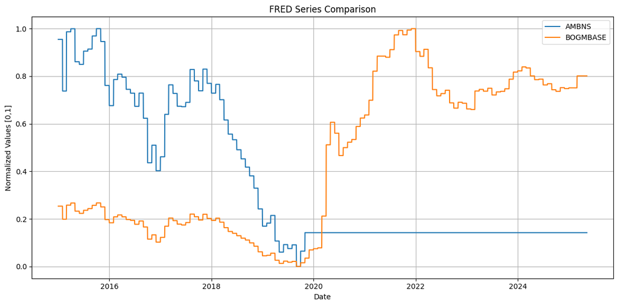

```python
fed_graph_gen(['AMBNS','BOGMBASE'],2015)
```

```python
run_xgboost_classification(ms_,['UNRATE', 'M2SL', 'RETAILMPCIMSA', 'PPIDTS', 'TMBACBM027SBOG', 'AMBNS'],'FEDFUNDS')
```

```
XGBoost Classification Report:
              precision    recall  f1-score   support

           0       0.63      0.55      0.59        22
           1       1.00      1.00      1.00      1802
           2       0.63      0.76      0.69        29

    accuracy                           0.99      1853
   macro avg       0.75      0.77      0.76      1853
weighted avg       0.99      0.99      0.99      1853
```

With our `fed_graph_gen` function we can plot our chosen FRED data on a time scale and make statistical inferences visually... If there is a small number of indicators. If we use the top ranked combination as our input we get a rather chaotic graph.

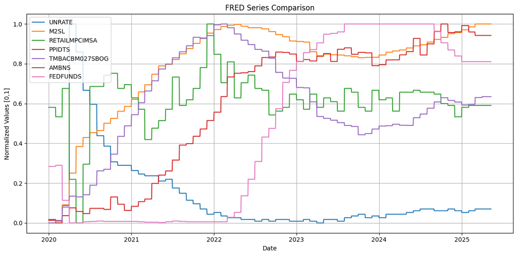

```python
fed_graph_gen(['UNRATE', 'M2SL', 'RETAILMPCIMSA', 'PPIDTS', 'TMBACBM027SBOG', 'AMBNS','FEDFUNDS'],2020)
```

For a better analysis we can observe a smaller set of combinations from the ranking list. Let's compare the effective interest rate (`FEDFUNDS`) against the money supply (`M2SL`), monthly retail inventory (`RETAILMPCIMSA`), and the circulation of currency (`BOGMBASE`).

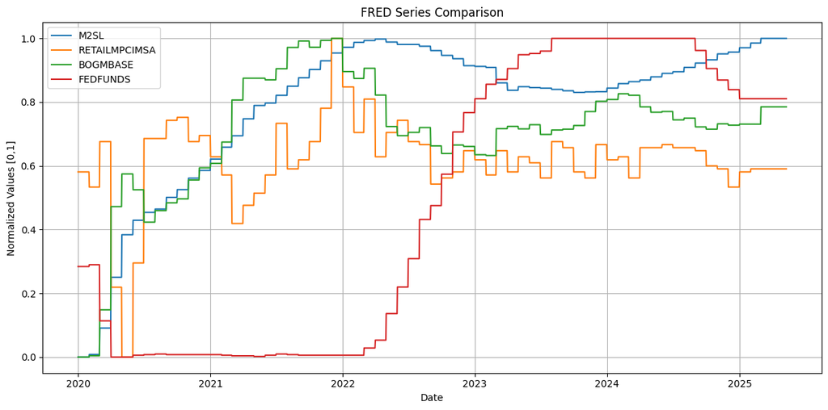

```python
fed_graph_gen(['M2SL', 'RETAILMPCIMSA', 'BOGMBASE','FEDFUNDS'],2020)
```

Upon observation, we can see that the effective interest rate has an inverse relationship to the amount of liquid assets (cash) that is being introduced to the economy, as well as the inventory supplied by retailers. In other words, as interest rates increase, the amount of cash being created is reduced to curtail inflation of the US dollar and retailers will have less inventory available for purchase for consumers since the cost of goods will be more expensive. When interest rates are cut, the production of cash increases to encourage economic activity and the inventory for consumer goods will increase as it is cheap for the producer to acquire and consumers will be in a financial position that allows them to spend liberally without concerns of debt or inflation.

But what about the daily economic indicators? Is it possible to make confident predictions based on information that is updated on a per day basis versus a 30-day interval? To find this out we can simply use the daily indicator dataframe from earlier as the parameters for our combinations function.

```python
daily_combo = test_feature_combinations(ds_, daily_series_ids, 'DFF', max_combination_size=7, top_n=20,t_size=0.2)
display(daily_combo)
```

[output not shown]

[output cut: 13 more lines]

[output not shown]

```python
daily_combo['Economic Indicator Combination'][0]
```

[output not shown]

```python
run_xgboost_classification(ds_,['FEDFUNDS',
 'RRPONTSYD',
 'THREEFY7',
 'THREEFF4',
 'BAMLEM4RBLLCRPIUSOAS',
 'RIFSPPFAAD01NB'],'DFF')
```

[output not shown]

To avoid the overcrowding of data on our graph we will once again choose a smaller set of indicators. For this instance, we will choose the monthly effective interest rate (`FEDFUNDS`), Overnight Reverse Repurchase Agreements (`RRPONTSYD`), Overnight AA Financial Commercial Paper Interest Rate (`RIFSPPFAAD01NB`) and the daily effective interest rate (`DFF`).

```python
fed_graph_gen(['FEDFUNDS', 'RRPONTSYD', 'RIFSPPFAAD01NB','DFF'],2020)
```

[output not shown]

## What Could You Do This Information?

Now that we have a model that can predict the trajectory of interest rates correctly more than half the time, the information can be applied to the stock market. More specifically, one could pull data from index funds such as the S&P 500 either from FRED or through Yahoo Finance via `yfinance`. If one is able to predict the federal reserve's interest rate and the trajectory of an index fund, then it is possible for one to guage whether the stock market is bullish or bearish and be able to hedge their investment portfolio during a bearish period and acquire more shares during a bullish period. This method of finding correlative data could also be applied to `yfinance` exclusively to find the best pair-trading combinations, however that is beyond the scope of this project since you would have to analyze the time series of hundreds of different public equities from both NASDAQ and the New York Stock Exchange (NYSE), possibly the London Stock Exchange (LSE) or the Japan Exchange Group (JPX) as well if you wanted to consider international companies which makes the process more computationally expensive, not to mention the possible API rate limits of `yfinance` and if the data is enough to make decisions that yield similarly to high frequency trading (HFT) firms that have access to paid real-time data for equities offered by brokerages and Bloomberg terminals.

## Conclusion

In summary, we were able to find which economic indicators had the highest correlation to the trajectory of the interest rate set by the Federal Reserve , specifically whether the effective interest rate will rise (indicates inflation and a possible recession), if it will be cut (recession is underway and the Fed wants to stimulate economic activity) or if it will remain neutral (the Fed has determined that the economy is at a satisifactory status-quo). This way of sorting through economic data is not only useful for determining the behavior of our central bank but could also be applicable to other central banks around the world (provided they have the similar recording practices) and could be used to determine the sentiment for the stock market in either equities (stocks) or derivatives (options and futures). Although institutions may be able to come up with more accurate ways of determining Fed policy, this model should suffice for retail traders as any tool or resource that accurately reflects on phenomena in the finance world, whether it be reading a balance sheet or analyzing the past behavior of the stock in comparison to economic data, would give an significant edge to the trader and make them stand out in a sea of traders that trade on gut feeling or emotion. Hopefully upon reading this report, one would take inspiration and be able to come up with ways of researching the economy and already have their assets prepared by the time Chairman Powell says "Good Evening" at the podium.

## References

- Chen, J. (2024, May 9). What is a reverse repurchase agreement (RRP)? How it works, with example. Investopedia. https://www.investopedia.com/terms/r/reverserepurchaseagreement.asp
- Federal Open Market Committee. (n.d.). https://www.federalreserve.gov/monetarypolicy/fomc.htm
- Federal Reserve Economic Data | FRED | St. Louis Fed. (n.d.). https://fred.stlouisfed.org/
- Installation Guide — xgboost 3.0.0 documentation. (n.d.). https://xgboost.readthedocs.io/en/stable/install.html
- Majaski, C. (2025, May 9). Producer Price Index (PPI): What It Is and How It's Calculated. Investopedia. https://www.investopedia.com/terms/p/ppi.asp
- Mitchell, R., & Mitchell, R. (2022, October 10). Gradient Boosting, Decision Trees and XGBoost with CUDA. NVIDIA Technical Blog. https://developer.nvidia.com/blog/gradient-boosting-decision-trees-xgboost-cuda/
- Monetary base: total. (2025a, April 22). https://fred.stlouisfed.org/series/BOGMBASE
- Peterstevens. (2024, June 20). How the Fed’s Overnight Reverse Repo Facility Works - Liberty Street Economics. Liberty Street Economics. https://libertystreeteconomics.newyorkfed.org/2022/01/how-the-feds-overnight-reverse-repo-facility-works/
- Segal, T. (2024, September 2). What is a central bank, and does the U.S. have one? Investopedia. https://www.investopedia.com/terms/c/centralbank.asp
- What is included in the M2 money supply? Investopedia. https://www.investopedia.com/terms/m/m2.asp
- What is XGBoost? (n.d.). NVIDIA Data Science Glossary. https://www.nvidia.com/en-us/glossary/xgboost/
- Wikipedia contributors. (2025, March 25). XGBoost. Wikipedia. https://en.wikipedia.org/wiki/XGBoost